# Proyecto 1

Aldo Gatica 1288813 - Alyson Rosales 1086622

2025-03-04

## Relación entre Gastos y Utilidad en Empresas de Estados Unidos

### Utilidad:

La utilidad es una métrica financiera clave que refleja la rentabilidad de una empresa. Se calcula como la diferencia entre los ingresos totales y los costos totales, incluyendo los gastos operativos, administrativos y de marketing. Maximizar la utilidad es uno de los principales objetivos de cualquier empresa, ya que permite reinvertir en el negocio, retribuir a los accionistas y garantizar la sostenibilidad a largo plazo.

### Gastos de Investigación y Desarrollo:

Los gastos de Investigación y Desarrollo (I+D) representan las inversiones que una empresa realiza en actividades destinadas a la innovación, creación de nuevos productos, mejora de procesos y desarrollo de tecnologías. Estas actividades son fundamentales para mantener la competitividad en mercados dinámicos y en constante evolución.

**Relación con la Utilidad:** En muchos sectores, especialmente en industrias tecnológicas, farmacéuticas y manufactureras, los gastos en I+D están directamente relacionados con la capacidad de una empresa para generar nuevos productos o mejorar los existentes, lo que puede traducirse en mayores ingresos y, por ende, en una mayor utilidad. Estudios empíricos han demostrado que las empresas que invierten más en I+D tienden a tener un mejor desempeño financiero a largo plazo.

### Gastos de Administración:

Los gastos de Administración incluyen los costos asociados con la gestión y operación general de la empresa, como salarios del personal administrativo, gastos de oficina, servicios públicos y otros costos operativos. Estos gastos son necesarios para mantener la estructura organizacional y garantizar el funcionamiento eficiente de la empresa.

**Relación con la Utilidad:** Aunque los gastos de administración son esenciales para el funcionamiento diario de una empresa, no siempre están directamente relacionados con la generación de ingresos. En muchos casos, estos gastos se consideran costos fijos que no varían significativamente con el nivel de producción o ventas. Por lo tanto, su impacto en la utilidad puede ser menos evidente en comparación con otros gastos más estratégicos, como los de I+D o marketing.

### Gastos de Marketing:

Los gastos de Marketing incluyen las inversiones en publicidad, promociones, relaciones públicas y otras actividades destinadas a aumentar la visibilidad de la empresa, atraer clientes y fomentar las ventas. El marketing es una herramienta clave para diferenciar productos y servicios en mercados competitivos.

**Relación con la Utilidad:** El marketing puede tener un impacto directo en las ventas y, por lo tanto, en la utilidad. Sin embargo, su efectividad depende de factores como la estrategia utilizada, el mercado objetivo y la competencia. En algunos casos, los gastos en marketing pueden no traducirse inmediatamente en mayores ganancias, especialmente si las campañas no están bien dirigidas o si el mercado está saturado.

```r
# Carga de datos
dataset <- read.csv("Empresas.csv")
head(dataset)
```

```
##   Investigacion_y_Desarrollo Administracion Marketing     Estado Utilidades
## 1                   165349.2      136897.80  471784.1   New York   192261.8
## 2                   162597.7      151377.59  443898.5 California   191792.1
## 3                   153441.5      101145.55  407934.5    Florida   191050.4
## 4                   144372.4      118671.85  383199.6   New York   182902.0
## 5                   142107.3       91391.77  366168.4    Florida   166187.9
## 6                   131876.9       99814.71  362861.4   New York   156991.1
```

El dataset contiene información sobre la utilidad y los gastos en Investigación y Desarrollo, Administración y Marketing de varias empresas en Estados Unidos. Las cantidades están expresadas en dólares.

## Análisis Exploratorio de Datos

Las variables de interés en este análisis son la utilidad y los gastos en Investigación y Desarrollo (I+D), Administración y Marketing. A continuación, se presentan algunas estadísticas descriptivas y visualizaciones para comprender mejor la distribución y relación entre estas variables.

```r
summary(dataset)
```

```
##  Investigacion_y_Desarrollo Administracion     Marketing
##  Min.   :     0             Min.   : 51283   Min.   :     0
##  1st Qu.: 39936             1st Qu.:103731   1st Qu.:129300
##  Median : 73051             Median :122700   Median :212716
##  Mean   : 73722             Mean   :121345   Mean   :211025
##  3rd Qu.:101603             3rd Qu.:144842   3rd Qu.:299469
##  Max.   :165349             Max.   :182646   Max.   :471784
##     Estado            Utilidades
##  Length:50          Min.   : 14681
##  Class :character   1st Qu.: 90139
##  Mode  :character   Median :107978
##                     Mean   :112013
##                     3rd Qu.:139766
##                     Max.   :192262
```

### Visualización de Datos

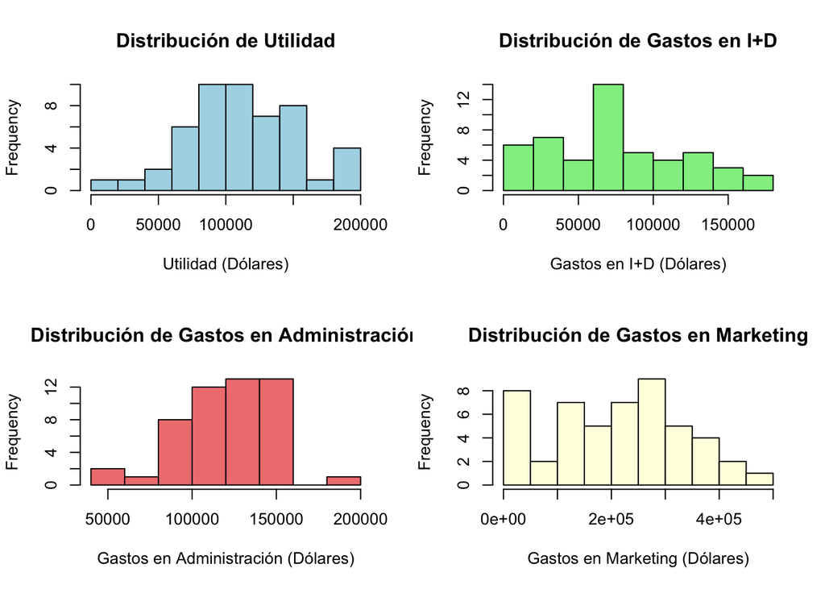

```r
par(mfrow=c(2,2))
hist(utilidad, main="Distribución de Utilidad", xlab="Utilidad (Dólares)", col="lightblue")
hist(inves, main="Distribución de Gastos en I+D", xlab="Gastos en I+D (Dólares)", col="lightgreen")
hist(admin, main="Distribución de Gastos en Administración", xlab="Gastos en Administración (Dólares)", col="lightcoral")
hist(marketing, main="Distribución de Gastos en Marketing", xlab="Gastos en Marketing (Dólares)", col="lightyellow")
```

### Desarrollo del modelo

El modelo de regresión lineal múltiple pretende predecir la utilidad en función de los gastos en I+D, administración y marketing. A continuación, se presenta el modelo inicial con las tres variables y el modelo final con las variables más significativas.

```r
### Modelo inicial con las tres variables
modeloprueba <- lm(utilidad ~ inves + admin + marketing, data = dataset)
summary(modeloprueba)
```

```
##
## Call:
## lm(formula = utilidad ~ inves + admin + marketing, data = dataset)
##
## Residuals:
##    Min     1Q Median     3Q    Max
## -33534  -4795     63   6606  17275
##
## Coefficients:
##               Estimate Std. Error t value Pr(>|t|)
## (Intercept)  5.012e+04  6.572e+03   7.626 1.06e-09 ***
## inves        8.057e-01  4.515e-02  17.846  < 2e-16 ***
## admin       -2.682e-02  5.103e-02  -0.526    0.602
## marketing    2.723e-02  1.645e-02   1.655    0.105
## ---
## Signif. codes:  0 '***' 0.001 '**' 0.01 '*' 0.05 '.' 0.1 ' ' 1
##
## Residual standard error: 9232 on 46 degrees of freedom
## Multiple R-squared:  0.9507, Adjusted R-squared:  0.9475
## F-statistic:   296 on 3 and 46 DF,  p-value: < 2.2e-16
```

```r
### Modelo final con dos variables
modelo <- lm(utilidad ~ inves + marketing, data = dataset)
summary(modelo)
```

```
##
## Call:
## lm(formula = utilidad ~ inves + marketing, data = dataset)
##
## Residuals:
##    Min     1Q Median     3Q    Max
## -33645  -4632   -414   6484  17097
##
## Coefficients:
##              Estimate Std. Error t value Pr(>|t|)
## (Intercept) 4.698e+04  2.690e+03  17.464   <2e-16 ***
## inves       7.966e-01  4.135e-02  19.266   <2e-16 ***
## marketing   2.991e-02  1.552e-02   1.927     0.06 .
## ---
## Signif. codes:  0 '***' 0.001 '**' 0.01 '*' 0.05 '.' 0.1 ' ' 1
##
## Residual standard error: 9161 on 47 degrees of freedom
## Multiple R-squared:  0.9505, Adjusted R-squared:  0.9483
## F-statistic: 450.8 on 2 and 47 DF,  p-value: < 2.2e-16
```

Los valores de R² son de 0.95 de modo que sí explica la variabilidad de la utilidad en función de los gastos en I+D y Marketing.

- Investigación (R&D Spend): El p-valor es de 2×10⁻¹⁶, confirmando que esta variable es altamente significativa.
- Marketing: El p-valor es 0.06, lo que indica que esta variable no es estadísticamente significativa en este modelo.

### Modelo de Regresión Lineal

**UTILIDAD = 46980 + 0.7966(INVESTIGACION) + 0.02991(MARKETING)**

### Análisis de Residuales

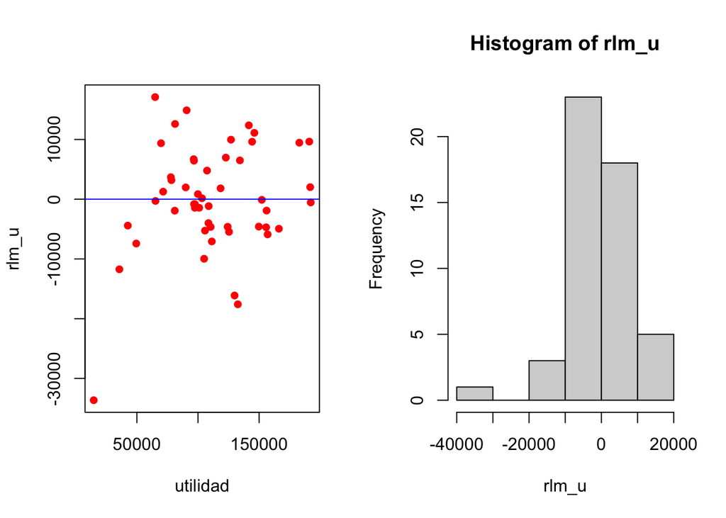

```r
rlm_u <- residuals(modelo)
par(mfrow=c(1,2))
plot(utilidad,rlm_u, pch=16, col="red")
abline(h=0, col="blue")
hist(rlm_u)
```

El gráfico de dispersión de los residuales no sigue un patrón, lo que sugiere que no hay heterocedasticidad.

```r
bptest(modelo)
```

```
##
##  studentized Breusch-Pagan test
##
## data:  modelo
## BP = 2.8431, df = 2, p-value = 0.2413
```

Los resultados de la prueba Breusch-Pagan indican con un p-value de 0.2413 que no hay heterocedasticidad en el modelo.

```r
shapiro.test(rlm_u)
```

```
##
##  Shapiro-Wilk normality test
##
## data:  rlm_u
## W = 0.93717, p-value = 0.01042
```

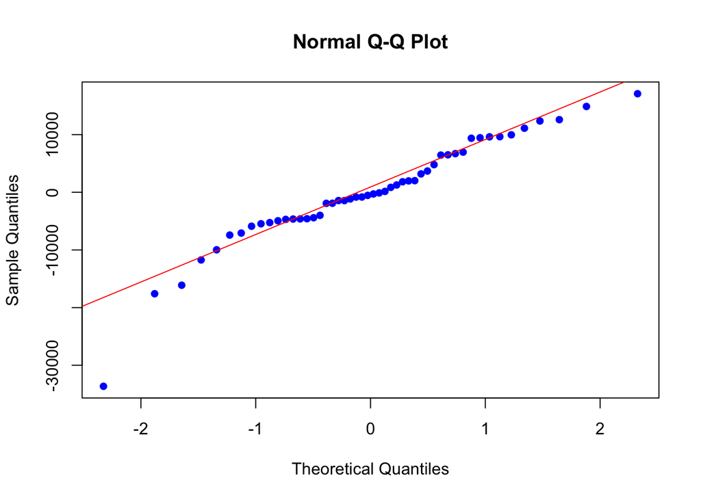

```r
qqnorm(rlm_u, pch = 16, col = "blue")
qqline(rlm_u, col = "red")
```

# Conclusiones

Este estudio confirma que las inversiones en I+D son un factor crítico para maximizar la utilidad en el entorno empresarial analizado, mientras que los gastos en administración y marketing tienen un impacto limitado en este contexto. Estos hallazgos tienen implicaciones estratégicas significativas, sugiriendo que las empresas deberían priorizar las inversiones en innovación y optimizar los gastos administrativos y de marketing para mejorar su eficiencia operativa y rentabilidad. Futuras investigaciones podrían explorar el impacto a largo plazo de estas variables y considerar la inclusión de otros factores, como el entorno competitivo o las condiciones macroeconómicas, para enriquecer el análisis.

# Bibliografía

- Udemy. (n.d.). Machine Learning A-Z: AI, Python & R[2025]. Retrieved from [https://www.udemy.com/course/machinelearning].
- Hall, B. H., & Mairesse, J. (2006). The impact of R&D investment on firm performance: Evidence from firm-level data. Journal of Productivity Analysis